# MODELLING CLASS PROBABILITIES VIA LOGISTIC REGRESSION

#### MÔ HÌNH HÓA XÁC SUẤT THÔNG QUA LOGISTIC REGRESSION

## **VIỆC LỰA CHỌN MÔ HÌNH**

Việc chọn mô hình cho từng vấn đề cụ thể đòi hỏi nhiều kinh nghiệm thực hành. Mỗi thuật toán có những đặc điểm riêng và dựa trên giả thuyết nhất định. Không có mô hình nào hoạt động tốt đối với tất cả các vấn đề khác nhau.

Trong thực tế, người ta thường so sánh kết quả của nhiều thuật toán khác nhau và chọn thuật toán cho kết quả tốt nhất.

Hiệu suất tính toán, cũng như khả năng dự đoán cũng phụ thuộc vào dữ liệu được sử dụng cho training. Năm bước chính cho việc xây dựng một thuật toán supervised learning có thể được tóm tắt như sau:

> 1. Lựa chọn đặc trưng và thu thập dữ liệu có gán nhãn
> 2. Chọn phương thức đánh gía mô hình
> 3. Lựa chọn mô hình, thuật toán tối ưu
> 4. Đánh giá mô hình
> 5. Tinh chỉnh

## **BẮT ĐẦU VỚI SCIKIT-LEARN**

**Scikit-learn** cung cấp một giao diện thân thiện và nhất quán với nhiều thuật toán phân loại được tối ưu hoá. Không những vậy, **sklearn** còn cung cấp nhiều hàm tiền xử lí dữ liệu, tinh chỉnh và đánh giá mô hình tiện lợi.

```python
from sklearn import datasets
import numpy as np

iris = datasets.load_iris() #tập dữ liệu hoa
#2: petal length (độ dài cánh hoa)
#3: petal width (độ rộng cánh hoa)
X = iris.data[:, [2, 3]]
y = iris.target
print('Class labels:', np.unique(y))
```

```
Class labels: [0 1 2]
```

Dữ liệu được chia khoảng 70% để trainning và 30% dùng để test.

```python
from sklearn.model_selection import train_test_split

X_train, X_test, y_train, y_test = train_test_split(
    X, y, test_size = 0.3, random_state = 1, stratify = y
)
```

```python
print('Label counts in y: ', np.bincount(y))
print('Label counts in y_train: ', np.bincount(y_train))
print('Label counts in y_test: ', np.bincount(y_test))
```

```
Label counts in y:  [50 50 50]
Label counts in y_train:  [35 35 35]
Label counts in y_test:  [15 15 15]
```

Chuẩn hóa các đặc trưng:

```python
from sklearn.preprocessing import StandardScaler

sc = StandardScaler()
sc.fit(X_train)
X_train_std = sc.transform(X_train)
X_test_std = sc.transform(X_test)
```

## **HUẤN LUYỆN MỘT PERCEPTRON BẰNG SCIKIT-LEARN**

```python
from sklearn.linear_model import Perceptron

ppn = Perceptron(eta0 = 0.1, random_state = 1) #eta0:learning_rate
ppn.fit(X_train_std, y_train)
```

```
Perceptron(alpha=0.0001, class_weight=None, early_stopping=False, eta0=0.1,
           fit_intercept=True, max_iter=1000, n_iter_no_change=5, n_jobs=None,
           penalty=None, random_state=1, shuffle=True, tol=0.001,
           validation_fraction=0.1, verbose=0, warm_start=False)
```

**Note**

```python
y_pred = ppn.predict(X_test_std)
print('Misclassified examples: %d' % (y_test != y_pred).sum())
```

```
Misclassified examples: 1
```

```python
from sklearn.metrics import accuracy_score

print('Accuracy: %.3f' % accuracy_score(y_test, y_pred, normalize = True))
```

```
Accuracy: 0.978
```

```python
print('Accuracy: %.3f' % ppn.score(X_test_std, y_test))
```

```
Accuracy: 0.978
```

```python
from matplotlib.colors import ListedColormap
import matplotlib.pyplot as plt

def plot_decision_regions(X, y, classifier, test_idx = None, resolution = 0.02):
    # setup marker generator and color map
    markers = ('s', 'x', 'o', '^', 'v')
    colors = ('red', 'blue', 'lightgreen', 'gray', 'cyan')
    cmap = ListedColormap(colors[:len(np.unique(y))])

    # plot the decision surface
    x1_min, x1_max = X[:, 0].min() - 1, X[:, 0].max() + 1
    x2_min, x2_max = X[:, 1].min() - 1, X[:, 1].max() + 1
    xx1, xx2 = np.meshgrid(np.arange(x1_min, x1_max, resolution),
                           np.arange(x2_min, x2_max, resolution))
    Z = classifier.predict(np.array([xx1.ravel(), xx2.ravel()]).T)
    Z = Z.reshape(xx1.shape)
    plt.contourf(xx1, xx2, Z, alpha=0.3, cmap=cmap)
    plt.xlim(xx1.min(), xx1.max())
    plt.ylim(xx2.min(), xx2.max())

    for idx, cl in enumerate(np.unique(y)):
        plt.scatter(x=X[y == cl, 0],
                    y=X[y == cl, 1],
                    alpha=0.8,
                    c=colors[idx],
                    marker=markers[idx],
                    label=cl,
                    edgecolor='black')

    # highlight test examples
    if test_idx:
        # plot all examples
        X_test, y_test = X[test_idx, :], y[test_idx]

        plt.scatter(X_test[:, 0],
                    X_test[:, 1],
                    c='',
                    edgecolor='black',
                    alpha=1.0,
                    linewidth=1,
                    marker='o',
                    s=100,
                    label='test set')
```

Training a perceptron model using the standardized training data:

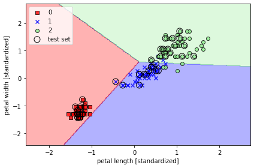

```python
X_combined_std = np.vstack((X_train_std, X_test_std))
y_combined = np.hstack((y_train, y_test))

plot_decision_regions(X=X_combined_std, y=y_combined,
                      classifier=ppn, test_idx=range(105, 150))
plt.xlabel('petal length [standardized]')
plt.ylabel('petal width [standardized]')
plt.legend(loc='upper left')

plt.tight_layout()
#plt.savefig('images/03_01.png', dpi=300)
plt.show()
# OvR: one vs the rest
# R G B
# R vs (G & B)
# G vs (R & B)
# B vs (R & G)
```

## **LOGISTIC REGRESSION AND CONDITIONAL PROBABILITIES**

Mặc dù Preceptron rule thường dùng để giới thiệu về thuật toán phân loại trong Machine Learning. Tuy nhiên, hạn chế lớn nhất của nó là sẽ không bao giờ hội tụ nếu dữ liệu các lớp không linearly separable.

Để giải quyết vấn đề này, có 1 thuật toán đơn giản, mạnh mẽ hơn là **Logistic Regression**.

**Logistic Regression** là 1 thuật toán phân loại nhị phân (**binary classification model**), không phải hồi quy (regression). Tương tự như Perceptron, đầu ra của Logistic Regression bị chặn ở 2 đầu (đoạn [0,1]). Mặt khác, ngoài chức năng phân loại nhãn dữ liệu, Logistic Regression còn có thể dự đoán xác suất của đầu ra dựa vào độ liên tục của dữ liệu. Vì thế, nó có tên là Logistic Regression.

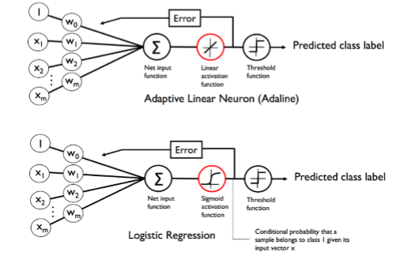

```python
Image(filename='example.PNG',width = 600)
```

## **TỈ SỐ ODD**

Gọi **p** là xác suất xảy ra của biến cố p => **ODD1 = p** Vậy xác suất không xảy ra các biến cố p là **1-p** => **ODD2 = 1-p**

Ta có tỉ số **Odd Ratio** (độ tương quan giữa 2 biến cố hay có thể nói là biến cố p có lợi hay không)

Do xác suất p xảy ra có giá trị trong khoảng **(0,1)** nên ta có thể **log-odds**, định nghĩa là **logit(p)**, phù hợp hơn cho các thuật toán hồi quy tuyến tính.

$OR:$ $\frac{ODD1}{ODD2}$ = $\frac{p}{1-p}$

$logit(p) = log\frac{p}{1-p}$

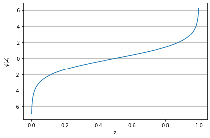

```python
import matplotlib.pyplot as plt
import numpy as np

def logit(p):
    return np.log(p/(1-p))

z = np.arange(0.001, 0.999, 0.001)
logit_z = logit(z)

plt.plot(z, logit_z)
plt.xlabel('z')
plt.ylabel('$\phi(z)$')
ax = plt.gca()
ax.yaxis.grid(True)

plt.tight_layout()
plt.show()
```

Hàm logit nhận giá trị đầu vào nằm trong khoảng (0,1) và biến đổi toàn bộ giá trị trên toàn bộ phạm vi số thực ($-\infty$,$+\infty$), khi đó ta có thể sử dụng để kết hợp quan hệ tuyến tính giữa các feature **z = $(w^Tx)$** và xác suất xảy ra **p**:

$logit(p(y=1|x)) = w_0x_0 + w_1x_1 + ... + w_mx_m = \sum{w_i}{x_i} = w^Tx $

$ln\frac{p}{1-p} = z$

$\Leftrightarrow \frac{p}{1-p} = e^z$

$\Leftrightarrow p = e^z(1-p) = e^z - e^zp$

$\Leftrightarrow p = \frac{e^z}{1+e^z} = \frac{1}{1+e^{-z}}$

Như vậy ta đặt $\phi(z) = \frac{1}{1+e^{-z}}$ là **activation function** của Logistic Regression. Hàm $\phi(z)$ có dạng sigmoid nên còn gọi là **(logistic) sigmoid function**.

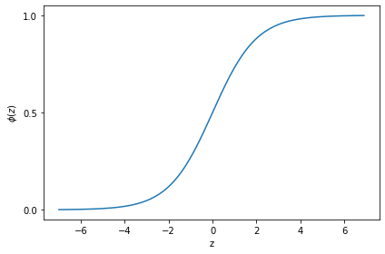

```python
import matplotlib.pyplot as plt
import numpy as np

def sigmoid(z):
    return 1.0/(1.0 + np.exp(-z))

z = np.arange(-7, 7, 0.1)
phi_z = sigmoid(z)

plt.plot(z, phi_z)
plt.xlabel('z')
plt.ylabel('$\phi(z)$')
plt.yticks([0.0, 0.5, 1.0])
ax = plt.gca()
ax.yaxis.grid(False)

plt.tight_layout()
plt.show()
```

Ta có thể thấy $\phi(z)$ tiệm cận 1 nếu z chạy tới $+\infty$ (vì $z$ càng lớn, $e^{-z}$ càng nhỏ), tương tự với tiệm cận 0. Do đó, ta có thể kết luận sigmoid function có thể nhận mọi giá trị $z$ thực và biến chúng thành các giá trị nằm trong đoạn $[0,1]$ và chặn ở $\phi(z) = 0.5$.

Ta đạo hàm $\phi(z)$:

$\phi'(z) = (\frac{1}{1+e^{-z}})' = \frac{e^{-z}}{(1+e^{-z})^2} = \frac{1}{1+e^{-z}}.\frac{e^{-z}}{1+e^{-z}} = \phi(z)(1-\phi(z)) (*)$

## **LOSS FUNCTION**

Nếu như MSE là phương pháp được sử dụng để ước tính các tham số trong Adaline thì trong Logistic Regression, ta dùng **maximum likelihood estimate** để ước tính tham số $w$.

Ta xét N mẫu dữ liệu được gán nhãn 0 và 1:(coi 2 nhãn là 2 biến cố)

> Ta thấy được, xác suất để 1 điểm dữ liệu được gán nhãn $y=1$ là $p(y=1|x_i;w) = \phi(z) = \phi(w^Tx_i)$

> Tương tự, xác suất để 1 điểm dữ liệu gán nhãn $y=0$ là $p(y=0|x_i;w) = 1 - \phi(w^Tx_i)$

Với 1 điểm dữ liệu $z_i = \phi(w^Tx_i)$, ta có thể viết chung 2 biểu thức trên dưới dạng:

$p(y_i|x_i;w) = z_i^{y_i}(1 - z_i)^{1-y_i}$

Mục đích là xác định hệ số $w$ sao cho các điểm dữ liệu ứng với từng biến cố nhất có thể. Vì thế ta cần miximize tất cả xác suất của các mẫu sao cho lớn nhất có thể. Bài toán trở thành **maximum likelihood estimation**.

Với 1 tập N mẫu dữ liệu và 2 nhãn 0 và 1, ta có xác suất có điều kiện tổng quát: $P(y_i|X;w) = \prod_{i \in \{y=1\}}\phi(z_i) x \prod_{i \in \{y=0\}}(1 - \phi(z_i)) = \prod_{i=1}^{N}z_i^{y_i}(1 - z_i)^{1-y_i}$

Đặt $P(y_i|X;w) = L(w)$, $L(w) = \prod_{i=1}^{N}z_i^{y_i}(1 - z_i)^{1-y_i}$ gọi là **likelihood function**.

Ta cũng có thể đơn giản hóa bằng cách lấy log hàm $L(w)$.

$l(w) = logL(w) = \sum_{i=1}^{N}[{y_i}{log(\phi(z_i))} + (1 - y_i)log(1 - \phi(z_i))]$

Hàm $l(w)$ gọi là **log-likelihood function**.

Sử dụng **log-likelihood function** để:

> Tối ưu để tránh trường hợp xảy ra lỗi trong tính toán (numberial error) nếu có $N$ lớn, tích trở nên quá nhỏ.

> Biến phép $*$ thành phép $+$, tránh việc số quá nhỏ và thuận tiện để đạo hàm.

Chuyển thành loss function, ta đổi dấu và dùng Gradient Descent để minimize hàm l(w)

$J(w) = -l(w) = - \sum_{i=1}^{N}[{y_i}{log(\phi(z_i))} + (1 - y_i)log(1 - \phi(z_i))]$

hoặc minimize dùng cost function tương tự Adaline (SSE): $J(w) = \sum_i \frac{1}{2}(\phi(z_i) - y_i)^2$

## **TỐI ƯU HÀM MẤT MÁT**

Ta có loss function tại 1 điểm dữ liệu $(x,y)$:

$j(\phi(z),y;w) = -ylog(\phi(z)) - (1 - y)log(1 - \phi(z))$

Nhìn vào công thức, ta có thể thấy: $$j(\phi(z),y;w) = \begin{cases} -log(\phi(z)) & if &y =1 \\ -log(1 - \phi(z)) & if &y =0 \end{cases}$$

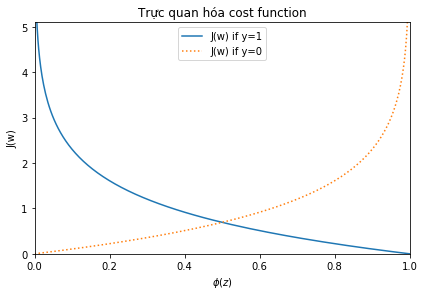

```python
def cost_1(z):
    return -np.log(sigmoid(z))

def cost_0(z):
    return -np.log(1 - sigmoid(z))

z = np.arange(-10, 10, 0.1)
phi_z = sigmoid(z)
c1 = [cost_1(x) for x in z]
c0 = [cost_0(x) for x in z]

plt.plot(phi_z, c1, label = 'J(w) if y=1')
plt.plot(phi_z, c0, linestyle=':', label = 'J(w) if y=0')

plt.ylim(0.0, 5.1)
plt.xlim([0,1])
plt.xlabel('$\phi(z)$')
plt.ylabel('J(w)')
plt.legend(loc = 'best')
plt.tight_layout()
plt.title('Trực quan hóa cost function')
plt.show()
```

Đạo hàm riêng chi phí theo w:

$\nabla{j(w)} = \frac{\partial}{\partial{w}}j(w) = -(ylog(\phi(z)) + (1 - y)log(1 - \phi(z))\frac{\partial}{\partial{w}} $

$ = - (y\frac{1}{\phi(z)} - (1 - y)\frac{1}{1-\phi(z)})\frac{\partial}{\partial{w}}\phi(z)$ (1)

Ta có: $\frac{\partial}{\partial{w}} = \frac{\partial}{\partial{w}}\frac{1}{1+e^{-z}} = \phi(z)(1 - \phi(z))\frac{\partial}{\partial{w}}z = \phi(z)(1 - \phi(z))x $ (vì đạo hàm z là x) (2)

Với (1) và (2), ta được:

$\frac{\partial}{\partial{w}}j(w) = -(y\frac{1}{\phi(z)} - (1 - y)\frac{1}{1-\phi(z)}) \phi(z) (1 - \phi(z)) x $

$= -(y - \phi(z))x$

Dựa vào Gradient Descent, ta có thể update 1 trọng số $w$ như sau: $w := w + \eta \sum_{i=1}^{N}(y_i - \phi(z_i)){x}_i $

Như vậy, với toàn dataset, trọng số $W$ sẽ được update: $W = W + \Delta{W}$ với cost function $J(W)$.

```python
class LogisticRegressionGD(object):
    '''Logistic Regression Classifier using gradient descent.

  Parameter
  ---------------
  eta : float
    Learning rate(between 0.0 and 1.0)
  n_iter : int
    Passes over the trainning dataaset.
  random_state : int
    Random number generator seed for random weight initialization.

  Attributes
  ---------------
  w_ : 1d-array
    Weights after fitting.
  cost_ : list
    Logistic cost function value in each epoch.
  '''
    def __init__(self, eta = 0.5, n_iter = 100, random_state =1):
        self.eta = eta
        self.n_iter = n_iter
        self.random_state = random_state

    def fit(self, X,y):
        '''Fit trainning data.

        Parameter
        -------------
        X: {array-like}, shape = [n_examples, n_features] (n mẫu/hàng, n chiều/cột)
          Trainning vectors, where n_examples is the number of examples
          and n_features is the number of features.
        y: array-like, shape = [n_examples] (n nhãn/điểm)
          Target values.

        Returns
        ------------
        self: object'''
        rgen = np.random.RandomState(self.random_state)
        self.w_ = rgen.normal(loc = 0.0, scale = 0.01, size = 1+X.shape[1])
        self.cost_ = []

        for i in range(self.n_iter):
            net_input = self.net_input(X)
            output = self.activation(net_input)
            errors = y - output
            self.w_[1:] += self.eta * X.T.dot(errors)
            self.w_[0]  += self.eta * errors.sum()

          # note that we compute the logistic 'cost' now
          # instead of the sum of squared errors cost

            cost = -y.dot(np.log(output)-(1-y).dot(1-np.log(1-output)))
            self.cost_.append(cost)
        return self

    def net_input(self, X):
        '''Calculate net input'''
        return np.dot(X, self.w_[1:]) + self.w_[0]

    def activation(self, z):
        '''Compute logistic sigmoid activation'''
        return 1./(1+np.exp(-np.clip(z, -250, 250)))

    def predict(self, X):
        '''Return class label after unit step'''
        return np.where(self.net_input(X) >= 0.0, 1, 0)
        # eqivalent to:
        # return np.where(self.activation(self.net_input(X)) >= 0.5, 1, 0)
```

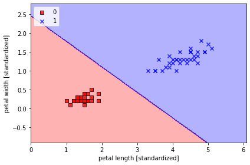

```python
X_train_01_subset = X_train[(y_train == 0) | (y_train == 1)]
y_train_01_subset = y_train[(y_train == 0) | (y_train == 1)]

lrgd = LogisticRegressionGD(eta=0.05, n_iter=1000, random_state=1)
lrgd.fit(X_train_01_subset,
         y_train_01_subset)

plot_decision_regions(X=X_train_01_subset,
                      y=y_train_01_subset,
                      classifier=lrgd)

plt.xlabel('petal length [standardized]')
plt.ylabel('petal width [standardized]')
plt.legend(loc='upper left')

plt.tight_layout()
plt.show()
```

## **TRAINING 1 MÔ HÌNH HỒI QUY LOGISTIC VỚI SCIKIT-LEARN**

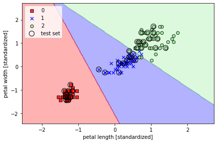

```
Accuracy: 0.978
```

```python
from sklearn.linear_model import LogisticRegression

lr = LogisticRegression(C=100.0, random_state=1, solver='lbfgs', multi_class='ovr')
lr.fit(X_train_std, y_train)

plot_decision_regions(X_combined_std, y_combined,
                      classifier=lr, test_idx=range(105, 150))
plt.xlabel('petal length [standardized]')
plt.ylabel('petal width [standardized]')
plt.legend(loc='upper left')
plt.tight_layout()
plt.show()
print('Accuracy: %.3f' % lr.score(X_test_std, y_test))
```

```python
lr.predict_proba(X_test_std[:3, :])
```

```
array([[3.81527885e-09, 1.44792866e-01, 8.55207131e-01],
       [8.34020679e-01, 1.65979321e-01, 3.25737138e-13],
       [8.48831425e-01, 1.51168575e-01, 2.62277619e-14]])
```

```python
lr.predict_proba(X_test_std[:3, :]).sum(axis=1)
```

```
array([1., 1., 1.])
```

```python
lr.predict_proba(X_test_std[:3, :]).argmax(axis=1)
```

```
array([2, 0, 0], dtype=int64)
```

```python
lr.predict(X_test_std[:3, :])
```

```
array([2, 0, 0])
```

## **XỬ LÝ OVERFITTING BẰNG REGULARIZATION**

Overfitting là một vấn đề cơ bản trong Machine Learning, xảy ra khi 1 mô hình cho hiệu suất tốt trên tập dữ liệu huấn luyện nhưng không tổng quát hóa được cho dữ liệu thực tế.

Ví dụ trong 1 mô hình học máy, ta cần tối ưu activation function nhất có thể ứng với tập dữ liệu trainning và dựa vào đó để phân loại/ dự đoán dữ liệu test. Mô hình càng khớp (*fit*) với dữ liệu thì càng tốt. Một mô hình tốt là mô hình có tính tổng quát. Nhưng nếu 1 mô hình quá *fit* thì sẽ gây ra *overfitting* vì quá cụ thể với dữ liệu train nên không biểu diễn tốt được đối với dữ liệu test. Ta nói mô hình đó không tổng quát.

Overfitting xảy ra khi dữ liệu train quá ít hay mô hình có độ phức tạp cao(nhiều tham số / độ lệch dữ liệu lớn).

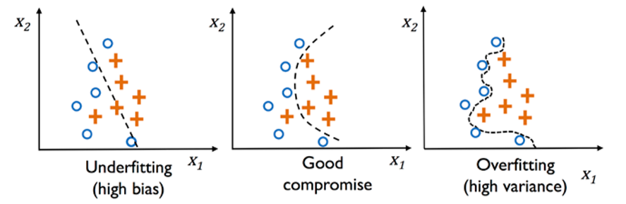

```python
from IPython.display import Image
Image(filename='overfitting.PNG')
```

Regularization là phương pháp để "trừng phạt" các điểm dữ liệu có trọng số cao.

Một phương pháp regularization phổ biến là **L2 REGULARIZATION** hay là **weight decay**.

Phương pháp này dùng để điều chỉnh độ phức tạp của mô hình bằng cách tăng hiệu suất của mô hình (giảm trọng số => giảm độ lệch dữ liệu).

$\frac{\lambda}{2}||w||_2^2 = \frac{\lambda}{2} \sum_{j=1}^m {w_j}^2$

$\lambda$ được gọi là **tham số chính quy** ($\lambda = \frac{1}{c}$) ví dụ, khi thêm công thức trên vào cost function của Logistic Regression, trọng số của dữ liệu sẽ được giảm bớt:

$J(w) = - \sum_{i=1}^N(y_ilog(\phi(z_i)) + (1 - y_i)log(1 - \phi(z_i))) + \frac{\lambda}{2}||w||_2^2$

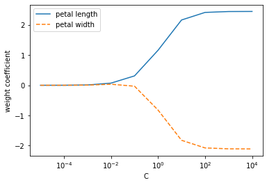

```python
weights, params = [], []
for c in np.arange(-5, 5):
    lr = LogisticRegression(C=10.**c, random_state=1,
                            solver='lbfgs',
                            multi_class='ovr')
    lr.fit(X_train_std, y_train)
    weights.append(lr.coef_[1])
    params.append(10.**c)

weights = np.array(weights)
plt.plot(params, weights[:, 0], label='petal length')
plt.plot(params, weights[:, 1], linestyle='--', label='petal width')
plt.ylabel('weight coefficient')
plt.xlabel('C')
plt.legend(loc='upper left')
plt.xscale('log')
plt.show()
```